# Social Media Advertising's Role in Small Business Resilience Amid Lockdowns

Converted from PDF `Lee-SocialAdvertisingBusinessResilience-2025-JIM.pdf` · 15 pages · anchors: page `#pN`, block `#pN-bK`

Page 1

## Social Media Advertising’s Role in Small Business Resilience Amid Lockdowns

Shun-Yang Lee , Julian Runge , Daniel Yoo , Yakov Bart , Anett Gyurak , and J.W. Schneider

Abstract Research has investigated the impact of the COVID-19 pandemic on business performance and survival, indicating particularly adverse effects for small and midsize businesses (SMBs). Yet only limited work has examined whether and how advertising may have helped shape these outcomes, particularly for SMBs. By constructing and analyzing a novel dataset of more than 79,000 businesses across 49 countries, the authors explore this question and examine the impact of pandemic-induced government stay-at-home orders on business survival. Using staggered difference-in-differences estimators, this research produces directional evidence that government lockdowns increased the likelihood of SMB closure and that social media advertising attenuated this adverse effect. These results are robust across different model specifications and measures of advertising activities. The findings additionally show heterogeneity across business sizes and industries, enriching the understanding of business survival during severe demand crises from a global perspective. The current research suggests that advertising may play an important role in building SMB resilience in light of severe demand shocks and mobility restrictions.

Keywords small business, social media advertising, COVID-19, lockdown, stay-at-home, business closure

Submitted November 18, 2024

The COVID-19 pandemic posed a serious threat to the operation of businesses around the world. As the pandemic unfolded, businesses were faced with the dire consequences of falling demand, declining revenues, and liquidity constraints. Indeed, as the pandemic intensified, businesses closed at an alarming rate (Apedo-Amah et al. 2020).<sup>1</sup> While the pandemic has increased researchers’ interest in understanding the extent and moderators of these closures (Bartik et al. 2020a; Bartlett and Morse 2020; Gourinchas et al. 2025; Wang et al. 2020), few insights exist into how advertising may have shaped the performance and operation of businesses around the world.

One reason for the lack of insight on the interaction of COVID-19 demand shocks, business operation, and advertising is the absence of a guiding theoretical framework for understanding whether/how advertising could help businesses operate in times of unexpected demand crises. While prior studies have examined how business outcomes, such as revenues (Bloom, Fletcher, and

Yeh 2021; Chetty et al. 2024), layoffs (Bartik et al. 2020a; Khamis et al. 2021), and business closures (Apedo-Amah et al. 2020; Crane et al. 2022), were affected during the pandemic, few studies have examined the extent to which advertising shaped these outcomes. Furthermore, advertising technology such as digital marketing channels can be particularly important for small and midsize businesses (SMBs) during such crises, as SMBs often mainly rely on digital channels for advertising; however, the literature is lacking in understanding whether/how such advertising technologies can affect SMB operations during demand crises.

Another reason for the lack of research is the paucity of data that observe both the advertising and operation of businesses

Shun-Yang Lee is Assistant Professor, D’Amore-McKim School of Business, Northeastern University, USA (email: sh.lee@northeastern.edu). Julian Runge is Assistant Professor, Medill School of Journalism, Northwestern University, USA (email: julian.runge@northwestern.edu). Daniel Yoo is Research Scientist, Meta Platforms, USA (email: danielyoo@meta.com). Yakov Bart is Professor, D’Amore-McKim School of Business, Northeastern University, USA (email: y.bart@northeastern.edu). Anett Gyurak is Director, Research, Meta Platforms, USA (email: anettg@meta.com). J.W. Schneider is Research Scientist, Meta Platforms, USA (email: john.schneider.work@gmail.com).

1 Apedo-Amah et al. (2020) find that the likelihood of business closures within four weeks of the peak of the COVID-19 pandemic around the world was more than 70%.

Research Report

Journal of Interactive Marketing

2025, Vol. 60(4) 362-376 © The Author(s) 2025

Article reuse guidelines: sagepub.com/journals-permissions DOI: 10.1177/10949968251336683

journals.sagepub.com/home/jnm

Page 2

during crises, such as the pandemic. Although there has been a critical need to understand how businesses were impacted by the pandemic, the sudden and rapid onset of COVID-19 has made it difficult to obtain timely and detailed data, especially outside a small group of regions and countries. In addition, recent efforts have focused on collecting data on a basic set of financial and employment indicators (Apedo-Amah et al. 2020; Bartik et al. 2020b; Chetty et al. 2024). Thus, the availability of advertising data has been limited by comparison, and, to the authors’ best knowledge, no studies have closely examined the role of advertising in business survival during the pandemic.

Therefore, in this research, we examine whether advertising impacted SMBs’ operations during the COVID-19 pandemic. Consisting of more than 79,000 businesses across 49 countries, our dataset combines firm-level time series of advertising activities on the Facebook platform with information on business operation and data on government lockdowns. We first investigate how governments’ stay-at-home orders affected the survival of businesses. We then explore whether Facebook advertising moderated the impact of stay-at-home orders on business operation and potential heterogeneity in the moderating effect. Our approach is exploratory in nature and focuses on providing directional evidence of advertising’s potential positive effects on SMBs during severe demand downturns.

Our empirical analyses utilize staggered difference-indifferences (DID) estimators. We find that governmentlockdowns during the pandemic led to an increase in business closures, but that social media advertising attenuated the impact of these lockdowns. These results are robust across different model specifications and measures of advertising activities. Our findings provide several important implications. First, we confirm that stay-at-home orders have a negative effect on business operation. Second, we find that advertising played an important role in supporting SMBs in navigating the hardships induced by the pandemic and related lockdowns. Third, we uncover effect heterogeneity across business sizes and industries using a global sample. While prior studies on the impact of stay-at-home orders have largely focused on a single country or region (Alexander and Karger 2023; Aum, Lee, and Shin 2021; Bartlett andMorse2020;GoolsbeeandSyverson2021),ourfindingshighlight the important role that advertising can play in building small business resilience using a global sample.

#### Literature Review

The COVID-19 pandemic has led to a growing body of research examining how businesses have been affected around the world. Notably, the role of government lockdowns and their impact on the performance and survival of businesses have been a major topic of interest. Alexander and Karger (2023) and Gourinchas et al. (2025) find that stay-at-home orders caused considerable reductions in consumer spending and led to increased failures among small businesses during the pandemic, respectively. Apedo-Amah et al. (2020) also find that business closures around the world were at their highest in the weeks following the most stringent periods of lockdown.

While research on business outcomes during the COVID-19 pandemic has grown rapidly since its onset, several important questions remain unanswered. First, how did advertising influence businesses during the pandemic? Second, to what extent are the results heterogeneous across different types of business? We expect advertising to have played a critical role in the performance and survival of businesses during the pandemic for both theoretical and empirical reasons. In particular, marketing theory posits that advertising activities have a long-term effect (Breuer and Brettel 2012; Reimer, Rutz, and Pauwels 2014) and that they can have a positive effect on future cash flows by supporting the development of market-based intangible assets (McAlister et al. 2016; Srivastava, Shervani, and Fahey 1998). Studies have also shown that advertising has an important influence on business survival, with past advertising both reducing the risk of bankruptcy (Jindal and McAlister 2015) and increasing the likelihood of surviving the bankruptcy process (Jindal 2020). In addition, studies have shown that personalized online advertising can enhance market-based intangible assets, including brand equity, by enhancing brand identification (Gordon, Moakler, and Zettelmeyer 2023; Tran et al. 2020). Personalized online advertising also has a positive impact on brand-specific page views (Rutz and Bucklin 2012), active and passive searches on a business’s web page (Ghose and Todri-Adamopoulos 2016), and both revenues and repeat purchase probabilities for businesses (Lewis and Reiley 2014; Manchanda et al. 2006). Moreover, Alekseev et al. (2023) provide initial evidence that Facebook advertising may have mitigated the adverse effect of the pandemic on businesses.<sup>2</sup> Given its ability to target and provide personalized content, we expect social media advertising to be effective in helping businesses accumulate market-based assets that support their financial performance during lockdowns, thereby increasing their likelihood of survival.

Therefore, this article aims to address these questions and offer new insights into the role of advertising for businesses during the pandemic, using a global sample.

#### Data and Measures Measuring Business Survival

We obtained data on business survival during the COVID-19 pandemic from the Future of Business Survey (FOBS). The FOBS is a joint data collection project conducted by the World Bank, the Organisation for Economic Co-operation and Development, and Facebook that collects survey data on the challenges, opportunities, and needs of businesses around the world using the Facebook platform. We use the FOBS data to construct an outcome variable of business operation by calendar month. Specifically, we construct panel data consisting of businesses and their monthly (binary) closure decision from December 2019 to May 2020. Tables 1 and 2 provide summary statistics for main continuous and categorical variables, respectively, broken down by whether the business ran any Facebook advertising campaign.

2 Note that Alekseev et al. (2023) focus on small businesses in the United States, whereas the current research considers a global sample.

Lee et al. 363

Page 3

#### Measuring Government Responses to the COVID-19 Pandemic

We obtain data on government responses to the COVID-19 pandemic from the Oxford COVID-19 Government Response Tracker, a data collection project that gathered information on the policies and interventions that governments around the world adopted in response to the pandemic. Our primary government response variable is the implementation of stay-at-home orders, which we treat as a binary measure. This variable captures the effects of lockdowns and movement restrictions. Operationally, we consolidate daily records of stay-at-home orders into monthly observations. We classify a month as having a stay-at-home order

in effect if the order was implemented for at least one day during the focal month.

#### Measuring Advertising Activities

We obtained advertising data from Facebook’s advertising database. Advertising on Facebook enables businesses to reach consumers who they believe will be most interested in their ads according to a variety of behavioral and demographic characteristics with highly personalized messages. A key benefit of using this data source is that it enables us to observe the actual advertising behavior for businesses in our sample as opposed to selfreported advertising behavior. We collected data on the

Table 1. Summary Statistics by Advertiser Status.

[output not shown]

NOTE: table converted from PDF layout to HTML text; cell boundaries are reconstructed. See PDF if exact alignment matters.

Notes: First treatment period = 0 represents businesses that were never treated. First treatment period = 1 represents December 2019, 2 represents January 2020, and so forth. Top 50% advertisers are those with an above-median number of active ads.

Table 2. Business Size and Industry by Advertiser Status.

[output not shown]

NOTE: table converted from PDF layout to HTML text; cell boundaries are reconstructed. See PDF if exact alignment matters.

Notes: Size is determined by number of employees.

364 Journal of Interactive Marketing 60(4)

Page 4

advertising use and spending history of businesses in the FOBS sample for our empirical analyses.

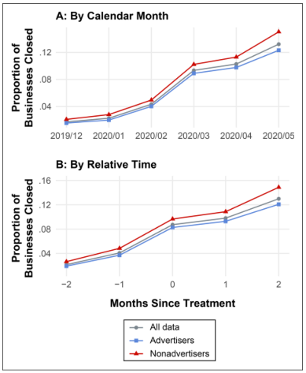

NOTE: figure/graphic rendered as an image from the PDF; its content is not machine-readable text. Caption (if any) follows as the next block.

#### Method

We use the collected data to examine how SMBs responded to governments’ stay-at-home orders during the COVID-19 pandemic and whether this relationship is moderated by their Facebook advertising activities. Since business closure is a binary outcome (i.e., open or close), we use a logit model for our analyses. Moreover, since some countries never issued any stay-at-home orders, we could use a DID approach to estimate the effect of the stay-at-home order on business closure, where weconsidergovernments’stay-at-homeordersasshocksandevaluate business closure as the outcome. However, since different countries issued the stay-at-home orders at different times, this means that the orders were enforced in a staggered fashion across countries. We therefore adopt a staggered DID model for our analysis. Specifically, we adopt an extended two-way fixed effect (ETWFE) approach (Berman and Israeli 2022; Wooldridge 2021, 2023) to model the staggered policy implementation. Intuitively, the ETWFE approach extends the two-way fixed effect model by adding additional interaction terms, including those between treatment and periods as well as between treatment and cohorts, where each cohort includes countries that adopted the treatment in the same period. The advantage of ETWFE is that it addresses the staggered adoption concern and can be applied to nonlinear models, and therefore we use ETWFE as our main modeling approach. As a robustness check, we also implement and present results from using the Callaway and Sant’Anna DID estimator (Callaway and Sant’Anna 2021). Additionally, we use our models to examine whether advertising activities on Facebook moderate the impact of governments’ stay-at-home orders. Operationally, we estimate the staggered DID models separately for advertisers and nonadvertisers, enabling us to compare their respective treatment effect estimates.

#### Model-Free Evidence

We begin by providing model-free evidence of the effect of stay-at-home orders on business closure. We visualize the proportion of businesses that closed separately for advertisers and nonadvertisers in Figure 1. We consider two ways of measuring time: calendar month and number of months since the implementation of stay-at-home orders (i.e., a relative time scale). We find that with both time measurements, advertisers exhibited lower closing proportions than nonadvertisers. Specifically, the relative time plot shows that the proportion of businesses that closed increased drastically as soon as stay-at-home orders took effect (i.e., when Months Since Treatment = 0), suggesting that stay-at-home orders are positively correlated with business closure. We also observe that advertisers exhibited a lower closing rate compared with nonadvertisers across different industries, as shown in Figure 2, and for small businesses (i.e., fewer than 500 employees), as shown in Figure 3. Overall, these

findings suggest that advertising might have moderated the effect of stay-at-home orders. We next present results from staggered DID analyses.

#### Modeling Results Main Effect of Stay-at-Home Orders on Business Closure

As described in the “Method” section, our main empirical model is an ETWFE with a logit link to evaluate the effect of stay-at-home orders on a binary outcome (i.e., business closure). We report the estimate of the average treatment effect on the treated (ATT) in Table 3, Column 1. The logit model result shows that the stay-at-home order leads to a 2.9 percentage point increase in business closure probability. We further report the event-study estimates of ATT in Table 3, Column 2, where we define a given period using the number of months since the treatment took effect. For example, ATT (0) represents the estimate for the period when treatment took effect. We find that the ATT estimates kept increasing post treatment. As a robustness check, in Table 3, Columns 3 and 4, we report a set of linear probability model (LPM) results of both the ATT and its event-study estimates, respectively. The LPM results are largely consistent with the logit results. Overall, we find that, consistent with

Figure 1. Proportion of Business Closures by Advertiser Status. Notes: The upper graph displays the closure proportion by calendar month, while the lower graph shows the closure proportion by relative time, with Months Since Treatment = 0 indicating the month in which the stay-at-home order went into effect.

Lee et al. 365

Page 5

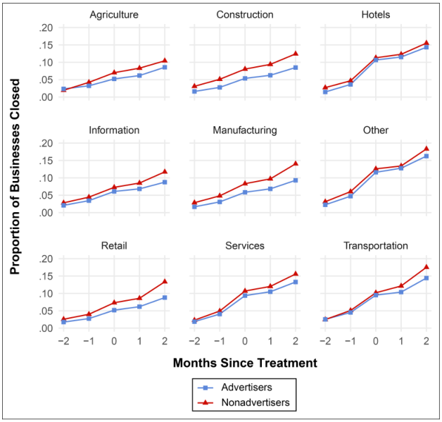

NOTE: figure/graphic rendered as an image from the PDF; its content is not machine-readable text. Caption (if any) follows as the next block.

expectations, the stay-at-home order is positively correlated with an increase in business closure probability.

#### Advertising’s Moderating Effects

To investigate advertising’s moderating effects, we examine the ATT separately for advertisers and nonadvertisers. We measure a business’s Facebook advertiser status using two different measures because advertising is known to have a lagged effect (Beaver, McNichols, and Rhie 2005; Jindal and McAlister 2015; Shumway 2001). The first measure represents a longer time frame, that is, using a business’s advertising activities in 2019, whereas the second measure represents a shorter time frame, that is, using the advertising activities two months prior to a given period. The results using both measures are reported in Table 4. We also visualize the ATT estimates for the 2019 data in Figure 4 and those for the two-month-lead data in Figure 5. We find that, while the ATT estimates are positive for both advertisers and nonadvertisers across all periods, the advertisers’ estimates are consistently lower than those of nonadvertisers. This provides

evidence that advertising might have attenuated the negative effect of stay-at-home orders.<sup>3,4</sup>

#### Alternative Modeling Framework

As a robustness check, we report the event-study type ATT results using the Callaway and Sant’Anna DID estimator (Callaway and Sant’Anna 2021), which we visualize in Figure 7 and display in Table 6. Column 1 shows the ATT estimates for the entire dataset, while Columns 2 and 3 report subgroup analyses results separately for advertisers and nonadvertisers, respectively. We again find that the ATT estimates for nonadvertisers are consistently larger than those of advertisers, consistent with the

Figure 2. Proportion of Business Closures by Industry and Advertiser Status. Notes: Each subplot presents the closure proportion over relative time for a specific industry, where Months Since Treatment = 0 denotes the month in which the stay-at-home order was implemented.

3 We additionally conduct the ETWFE analysis including business fixed effects. Note that by including business fixed effects, we lose potentially relevant withincountry variations. We report the results in Table 5. The ATT estimates are consistent with the main results, while the results of the event-study estimates are mixed. 4 We consider an alternative classification in which we classify a month as having a stay-at-home order in effect if the order was implemented for at least two days during the focal month. The regression results are almost identical and are displayed in Figure 6.

366 Journal of Interactive Marketing 60(4)

Page 6

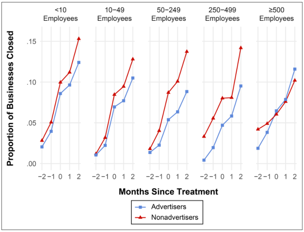

NOTE: figure/graphic rendered as an image from the PDF; its content is not machine-readable text. Caption (if any) follows as the next block.

ETWFE estimates reported previously. We also notice that the ATT estimate for period −1 (i.e., one month prior to the implementation of the stay-at-home order) is significant for the overall data and for the nonadvertiser subgroup. This suggests there might have been an anticipation effect, causing more businesses to close even before the stay-at-home order took effect. Nevertheless, this appears to be mostly driven by nonadvertisers.<sup>5</sup>

#### Alternative Advertising Measures

Recall that in the preceding analyses, we used advertiser status to categorize businesses into advertisers and nonadvertisers. We explore three alternative measures of advertising activities. First, we use the number of ads published to categorize businesses into two halves (i.e., top 50% and bottom 50%) using the median number of active Facebook ads as the threshold. We repeat the ETWFE logit analysis for the two subgroups and report the results in Table 7 and Figure 8. The results again demonstrate that active advertisers had a lower ATT than nonadvertisers.

Table 3. Effect of Stay-at-Home Order on Business Closure Probability (ETWFE).

|  | Logit(ATT) | Logit(Event) | LPM(ATT) | LPM(Event) |
| --- | --- | --- | --- | --- |
| ATT | 029(008)*** . . |  | 036(007)*** . . |  |
| ATT(0) |  | 022(009)** . . |  | 032(010)** . . |
| ATT(1) |  | 027(007)*** . . |  | 030(006)*** . . |
| ATT(2) |  | 035(009)*** . . |  | 041(008)*** . . |
| ATT(3) |  | 038(007)*** . . |  | 050(002)*** . . |
| ATT(4) |  | 115(017)*** . . |  | 151(003)*** . . |
| R2 | 080 . | 080 . | 041 . | 041 . |

NOTE: table converted from PDF layout to HTML text; cell boundaries are reconstructed. See PDF if exact alignment matters.

**p < .01. ***p < .001. Notes: The table shows ETWFE (Wooldridge 2021) estimates of ATT, controlling for country gross domestic product (GDP) per capita, business size, and social media popularity (number of Facebook fans). Treatment is the implementation of a stay-at-home order. Outcome is the treatment effect on business closure probability. ATT (Period) refers to the number of months since the treatment took effect (e.g., Period = 2 means two months after the treatment took effect). ETWFE mechanically sets coefficients of pretreatment periods to 0, and thus these coefficients are omitted in the table. Standard errors are clustered at the country level.

Figure 3. Proportion of Business Closures by Size and Advertiser Status. Notes: Each subplot displays the closure proportion over relative time for a specific business size category, where size is defined by the number of employees and is indicated above each subplot.

5 Note that the ETWFE model mechanically sets all pretreatment period ATT estimates to 0, and therefore we are unable to assess the pretreatment trends in the main model.

Lee et al. 367

Page 7

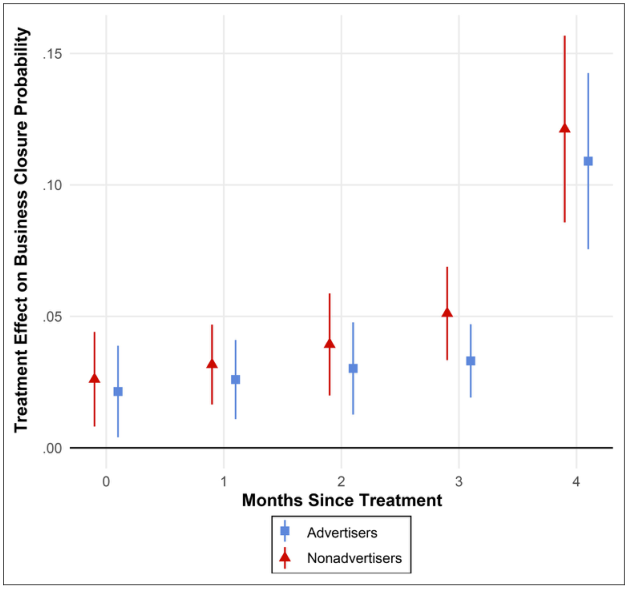

NOTE: figure/graphic rendered as an image from the PDF; its content is not machine-readable text. Caption (if any) follows as the next block.

Second, among advertisers, we use their ad spending amounts to categorize businesses into five quintiles, with Quintile 1 being the smallest and Quintile 5 the largest in terms of ad spending. We then compute the ATT estimates for the five quintiles separately and report the ETWFE results in Table 8, Row 1. We

find that businesses with higher ad spending had lower ATT estimates than those with lower ad spending.

Third, businesses’ advertising decisions could be driven by some unobserved factors, leading to endogeneity concerns. To this end, we construct another advertising measure using the

Table 4. Moderating Effect of Advertising on ATT (ETWFE-Logit).

|  | AdvertiserStatus | Advertiser Status (Two-Month Lead) |
| --- | --- | --- |
|  | Nonadvertisers Advertisers | Nonadvertisers Advertisers |
| ATT(0) | 026(009)** 021(009)* . . . . | 037(013)** 035(011)** . . . . |
| ATT(1) | 032(008)*** 026(008)*** . . . . | 047(012)*** 045(010)*** . . . . |
| ATT(2) | 039(010)*** 030(009)*** . . . . | 067(015)*** 059(012)*** . . . . |
| ATT(3) | 051(009)*** 033(007)*** . . . . | 080(012)*** 062(009)*** . . . . |
| ATT(4) | 121(018)*** 109(017)*** . . . . | 098(020)*** 093(018)*** . . . . |

NOTE: table converted from PDF layout to HTML text; cell boundaries are reconstructed. See PDF if exact alignment matters.

Figure 4. ATT Event-Study Estimates by Advertiser Status. Notes: The treatment is defined as the implementation of a stay-at-home order. Estimates are derived from an ETWFE-logit model.

368 Journal of Interactive Marketing 60(4)

Page 8

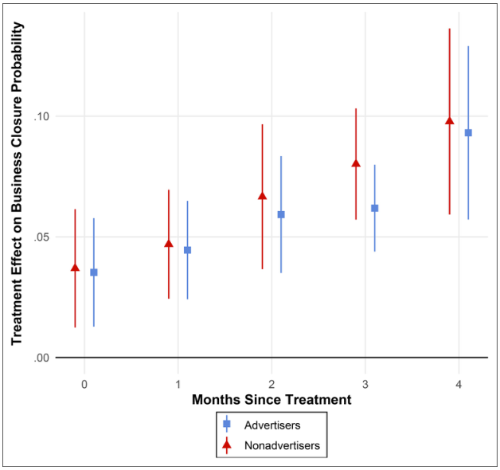

NOTE: figure/graphic rendered as an image from the PDF; its content is not machine-readable text. Caption (if any) follows as the next block.

industry average of ad spending. Specifically, for a focal business, we measure its ad spending using the average spending of its competitors in the same industry and country, excluding its own expenditures. The advantage of this approach is that, while the industry

average is likely correlated with the focal business’s ad spending, it will likely be uncorrelated with the unobserved factors unique to the focal business, alleviating the endogeneity concerns. We similarly categorize businesses into five quintiles based on the industry

Figure 5. ATT Event-Study Estimates by Advertiser Status with Two-Month Lead. Notes: Advertising data are based on a two-month lead. The treatment is defined as the implementation of a stay-at-home order. Estimates are derived from an ETWFE-logit model.

Table 5. Effect of Stay-at-Home Order on Business Closure Probability (ETWFE) with Business Fixed Effects.

|  | Logit(ATT) |  | Logit(Event) |  |
| --- | --- | --- | --- | --- |
|  | Nonadvertisers | Advertisers | Nonadvertisers | Advertisers |
| ATT | 034(011)** . . | 030(008)*** . . |  |  |
| ATT(0) |  |  | 018(016) . . | 023(009)* . . |
| ATT(1) |  |  | 033(013)* . . | 029(007)*** . . |
| ATT(2) |  |  | 047(011)*** . . | 034(009)*** . . |
| ATT(3) |  |  | 039(014)** . . | 041(007)*** . . |
| ATT(4) |  |  | 111(015)*** . . | 122(012)*** . . |

NOTE: table converted from PDF layout to HTML text; cell boundaries are reconstructed. See PDF if exact alignment matters.

*p < .05. **p < .01. ***p < .001. Notes: The table shows ETWFE (Wooldridge 2021) estimates of ATT, controlling for business fixed effects. Treatment is the implementation of a stay-at-home order. Outcome is the treatment effect on business closure probability. ATT (Period) refers to the number of months since the treatment took effect (e.g., Period = 2 means two months after the treatment took effect). ETWFE mechanically sets coefficients of pretreatment periods to 0, and thus these coefficients are omitted in the table. Standard errors are clustered at the country level.

Lee et al. 369

Page 9

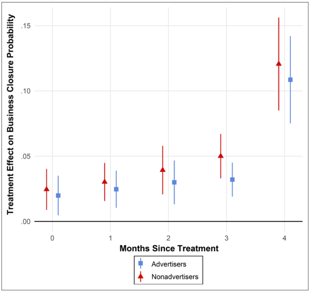

NOTE: figure/graphic rendered as an image from the PDF; its content is not machine-readable text. Caption (if any) follows as the next block.

average and report the ETWFE results in Table 8, Row 2. We again find that, when spending is measured using the industry average, businesses with higher ad spending continued to have lower ATT estimates than those with lower ad spending.

Overall, the results using these alternative advertising measures provide additional support for our argument that advertising helps alleviate the adverse effect of stay-at-home orders and increase business resilience.

#### Results by Business Size and Industry

We explore the heterogeneous effect of stay-at-home orders and advertising’s moderating effect in this section. Figure 9 displays the ATT estimates broken down by business size (indicated by the number of employees). We find that advertising appears particularly effective for small businesses compared with large businesses. Note that these results are directional as the estimates are imprecise.

We also break down the ATT estimates by industry sectors, as shown in Figure 10. We again see variations in both the ATT estimates and advertising’s moderating effects across industries. For example, retail and construction industries

appear to have benefited more from Facebook advertising, while advertising barely made any difference in the transportation industry and even had a negative effect on the agriculture industry. Nevertheless, directionally, Facebook advertisers in all industries (except for agriculture, which accounts for around 2% of the data) have lower ATT estimates compared with their nonadvertiser counterparts.

In summary, our analyses show that, while stay-at-home orders increased business closure overall, the adverse effects were less severe for social media advertisers than for nonadvertisers. The results are robust across different model specifications and measures of advertising activities. We observed similar trends across businesses of different sizes and industries.

#### Conclusion

In this study, we set out to examine whether governments’ stay-at-home orders affected SMB operation during the COVID-19 pandemic and the potential moderating role of social media advertising, focusing on Facebook data. Analyzing data from more than 79,000 businesses across 49 countries, we show that government lockdowns led to an

Figure 6. ATT Event-Study Estimates by Advertiser Status, Using an Alternative Stay-at-Home Order Classification (ETWFE). Notes: A month is classified as treated if a stay-at-home order was in effect for at least two days.

370 Journal of Interactive Marketing 60(4)

Page 10

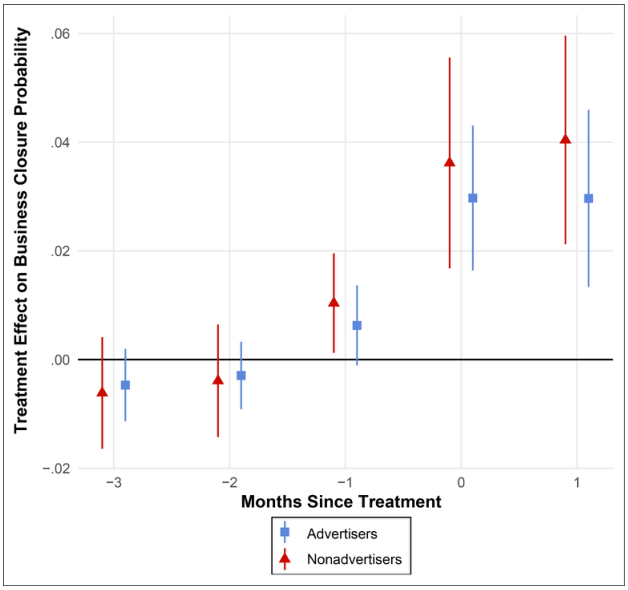

NOTE: figure/graphic rendered as an image from the PDF; its content is not machine-readable text. Caption (if any) follows as the next block.

We believe our exploration contributes to the literature in several ways. First, we analyze an original and unique dataset and uncover evidence that lockdowns indeed intensified business closures globally and across industries (Alexander and Karger 2023; Gourinchas et al. 2025). Second, we extend the literature by investigating whether

and how advertising was a useful tool for SMBs during the pandemic. Prior research has shown that advertising in general helps U.S. businesses survive during times of economic turbulence (Angulo-Ruiz et al. 2022; Jindal and McAlister 2015), but the impact of online advertising in particular on business survival is not well understood in a global context. Our findings indicate that online advertising played an important role in alleviating some of the adversity businesses faced during the pandemic. These directional findings

Figure 7. ATT Event-Study Estimates by Advertiser Status (Callaway and Sant’Anna DID Estimator). Notes: Estimates are derived from the Callaway and Sant’Anna DID estimator and aggregated using balance_e = 1. A significant result one month prior to treatment suggests the presence of an anticipation effect.

Table 6. Moderating Effect of Advertising on ATT (Callaway and Sant’Anna DID Estimator).

|  | Overall | Advertiser | Nonadvertiser |
| --- | --- | --- | --- |
| ATT( 3) − | 005[ 010 000]a −. −. , . | 005[ 011 002] −. −. , . | 006[ 016 004] −. −. , . |
| ATT( 2) − | 003[ 008 002] −. −. , . | 003[ 009 003] −. −. , . | 004[ 014 006] −. −. , . |
| ATT( 1) − | 008[002 013]a . . , . | 006[ 001 014] . −. , . | 010[001 020]a . . , . |
| ATT(0) | 032[022 042]a . . , . | 030[016 043]a . . , . | 036[017 056]a . . , . |
| ATT(1) | 033[022 044]a . . , . | 030[013 046]a . . , . | 040[021 060]a . . , . |

NOTE: table converted from PDF layout to HTML text; cell boundaries are reconstructed. See PDF if exact alignment matters.

aThe confidence band does not cover 0. Notes: The table shows Callaway and Sant’Anna DID estimates of ATT, broken down by advertiser status, controlling for business size and social media popularity (number of Facebook fans). The range in brackets represents the 95% simultaneous confidence band.

Lee et al. 371

Page 11

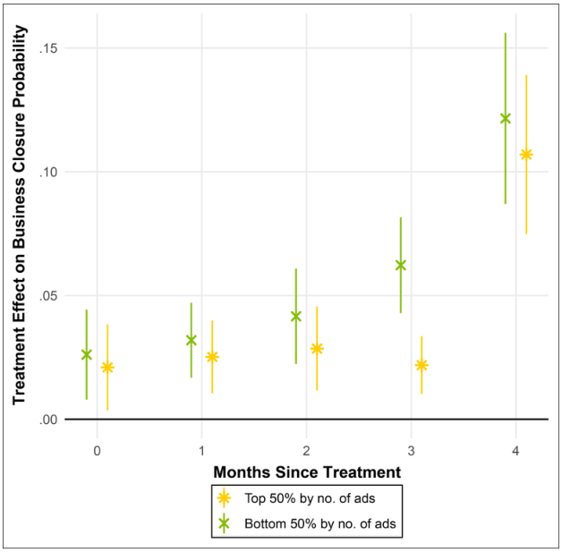

NOTE: figure/graphic rendered as an image from the PDF; its content is not machine-readable text. Caption (if any) follows as the next block.

are all the more important as reports suggest that firms have historically tended to cut back rather than increase marketing investments in times of severe economic turmoil (Özturan, Özsomer, and Pieters 2014; Rollins, Nickell, and Ennis

2014). Third, our findings are consistent with the view that advertising improves business performance through a lagged effect. Our study suggests that, directionally, advertising technology may serve as “insurance” against sudden

Table 7. Moderating Effect of Advertising on ATT (Number of Ads).

|  |  | AlternativeAdMeasurebyNumberofAds |  |
| --- | --- | --- | --- |
|  | Bottom50% |  | Top50% |
| ATT(0) | 026(009)** . . |  | 021(009)* . . |
| ATT(1) | 032(008)*** . . |  | 025(008)*** . . |
| ATT(2) | 042(010)*** . . |  | 029(009)*** . . |
| ATT(3) | 062(010)*** . . |  | 022(006)*** . . |
| ATT(4) | 122(018)*** . . |  | 107(016)*** . . |

NOTE: table converted from PDF layout to HTML text; cell boundaries are reconstructed. See PDF if exact alignment matters.

*p < .05. **p < .01. ***p < .001. Notes: The table shows ETWFE (Wooldridge 2021) estimates of ATT by the number of active ads, controlling for country GDP per capita, business size and social media popularity (number of Facebook fans). Top 50% advertisers are defined as those with an above-median number of active ads. Standard errors are clustered at the country level.

Figure 8. ATT Event-Study Estimates by Number of Active Ads (ETWFE). Notes: Top 50% advertisers are defined as those with an above-median number of active ads.

372 Journal of Interactive Marketing 60(4)

Page 12

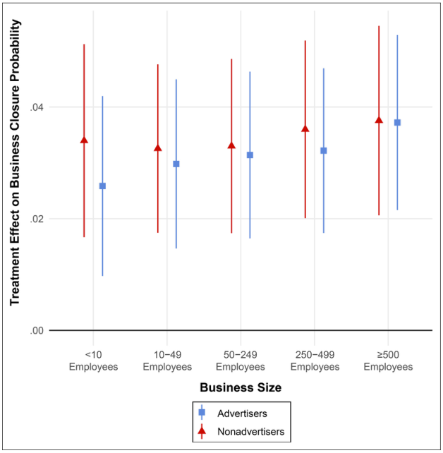

NOTE: figure/graphic rendered as an image from the PDF; its content is not machine-readable text. Caption (if any) follows as the next block.

and extreme demand shocks (Lewis and Reiley 2014; Manchanda et al. 2006). The findings further highlight that marketing technology can play an important role in building SMB resilience in light of severe demand shocks (Chandy et al. 2021).

Our findings provide important implications for stakeholders. For businesses, maintaining or even increasing social media advertising during times of crisis can be a counterintuitive but potentially beneficial strategy, as it helps build market-based intangible assets such as brand recognition and customer

Table 8. ATT Estimates by Ad Spending Quintiles.

|  |  |  | Quintiles |  |  |
| --- | --- | --- | --- | --- | --- |
|  | 1 | 2 | 3 | 4 | 5 |
| 1 | 043(009)*** . . | 031(009)*** . . | 025(008)** . . | 022(007)** . . | 020(006)** . . |
| 2 | 033(012)** . . | 020(010)* . . | 025(011)* . . | 019(012) . . | 018(012) . . |

NOTE: table converted from PDF layout to HTML text; cell boundaries are reconstructed. See PDF if exact alignment matters.

*p < .05. **p < .01. ***p < .001. Notes: The table shows ETWFE (Wooldridge 2021) estimates of ATT by quintiles. Quintile 1 contains businesses with the lowest ad spending; Quintile 5 contains businesses with the highest ad spending. In Row 1, quintile categorization uses the ad spending amount only among advertisers. In Row 2, quintile categorization is applied to ad spending measured using the average spending of competitors in the same industry and country (excluding own expenditures). Treatment is the implementation of a stay-at-home order. Outcome is the treatment effect on business closure probability. Results show that businesses with the highest ad spending were affected less by the stay-at-home order, controlling for country GDP per capita, business size, and social media popularity (number of Facebook fans).

Figure 9. ATT Estimates by Business Size and Advertiser Status (ETWFE). Notes: Size is defined by the number of employees.

Lee et al. 373

Page 13

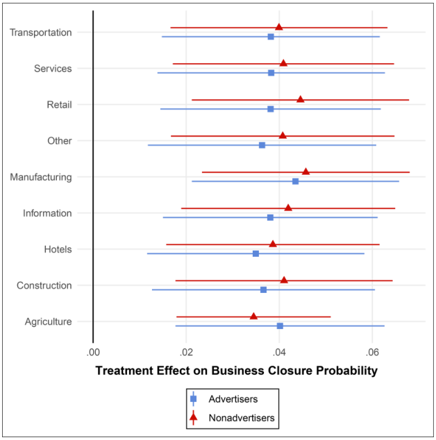

NOTE: figure/graphic rendered as an image from the PDF; its content is not machine-readable text. Caption (if any) follows as the next block.

engagement. A potential implication for policy makers is to consider subsidizing SMBs’ social media advertising campaigns, especially during economic downturns. Financial institutions in turn could consider providing credit lines or loans to assist SMBs in sustaining their social media advertising campaigns during financial hardships.

Our study has several limitations, mostly originating from the correlational nature of our findings. First, in addition to stay-at-home orders, governments around the world also implemented different economic and health policies during the pandemic, which we did not take into account in the current research. Future research should examine the effect of different policies on business operations. Second, we used Facebook advertising as the sole source of online advertising data. While most SMBs are likely to rely on prominent digital advertising platforms such as Facebook as their main advertising channels, we cannot rule out the possibility that there might have been other unobserved advertising activities. Third, we did not observe and thus could not control for key business characteristics such as financial health and age. Furthermore, businesses’ advertising decisions are inherently endogenous and

depend on their own performance as well as that of their competitors, leading our analyses to be correlational in nature. We encourage future research to carefully address the endogeneity concern.

Nevertheless, we believe our research raises important questions that have potential to enrich the scientific discourse (Golder et al. 2023). The first question is whether our findings apply to other modes of online advertising. The predictions provided by our analysis are not limited to the use of Facebook advertising, and we expect that different modes of online advertising, such as banner ads and search advertising, might also have supported the performance and survival of businesses during the pandemic. The second question is whether online advertising technology was especially relevant during the pandemic in light of the increase in internet usage and e-commerce expansion. More fully understanding how different modes of advertising interacted with the increased internet usage during the pandemic is important. While our study focuses on Facebook advertising, gaining insights into SMBs’ overall advertising spending and allocation across different media and channels would shed further light on the role of online

Figure 10. ATT Estimates by Industry and Advertiser Status (ETWFE).

374 Journal of Interactive Marketing 60(4)

Page 14

advertising in enhancing business resilience—including potential interaction effects between different media. The third question is whether specific targeting goals and/or strategies in social media advertising could further alleviate the negative effects of stay-at-home orders. As social media platforms have the ability to tailor the ad display to suitable users, it is possible that a carefully designed targeting strategy could amplify the moderating effect, which future research can investigate. Finally, as the odds of the next pandemic occurring are likely to increase (Bloomberg News 2023), it is imperative that we deepen our understanding of how social media advertising can most effectively enhance small business resilience.

Editor

Beth Fossen

Declaration of Conflicting Interests

The author(s) declared the following potential conflicts of interest with respect to the research, authorship, and/or publication of this article: The authors would like to note that two of the authors, Anett Gyurak and Daniel Yoo, are employed by the company providing the advertising data (Meta Platforms). J.W. Schneider was employed by Meta Platforms, and Julian Runge was employed by Facebook (before renaming of the company to Meta Platforms). Julian Runge further worked as an independent consultant for Meta Platforms in the past, in a capacity fully unrelated to this article.

Funding

The author(s) received no financial support for the research, authorship, and/or publication of this article.

ORCID iDs

Shun-Yang Lee https://orcid.org/0000-0002-5372-3849 Julian Runge https://orcid.org/0000-0002-7761-0515 Daniel Yoo https://orcid.org/0009-0005-8273-9486 Yakov Bart https://orcid.org/0000-0002-4094-9873 Anett Gyurak https://orcid.org/0009-0001-7197-2785 J.W. Schneider https://orcid.org/0009-0005-3102-6005

References

Alekseev, Georgij, Safaa Amer, Manasa Gopal, Theresa Kuchler, John

W. Schneider, Johannes Stroebel, and Nils Wernerfelt (2023), “The Effects of COVID-19 on U.S. Small Businesses: Evidence from Owners, Managers, and Employees,” Management Science, 69 (1), 7–24. Alexander, Diane and Ezra Karger (2023), “Do Stay-at-Home Orders

Cause People to Stay at Home? Effects of Stay-at-Home Orders on Consumer Behavior,” Review of Economics and Statistics, 105 (4), 1–11. Angulo-Ruiz, Fernando, Naveen Donthu, Diego Prior, and Josep Rialp-Criado (2022), “Funding Marketing Resources and Capabilities During a Recession: An Empirical Examination of Top Corporate Advertisers,” European Journal of Marketing, 56 (8), 2138–71. Apedo-Amah, Marie Christine, Besart Avdiu, Xavier Cirera, Marcio Cruz, Elwyn Davies, Arti Grover, Leonardo Iacovone,

Umut Kilinc, Denis Medvedev, Franklin Okechukwu Maduko, Stavros Poupakis, Jesica Torres, and Trang Thu Tran (2020), “Unmasking the Impact of Covid-19 on Businesses: Firm Level Evidence from Across the World,” World Bank Group Policy Research Working Paper 9434 (October), https://documents1.- worldbank.org/curated/en/399751602248069405/pdf/Unmaskingthe-Impact-of-COVID-19-on-Businesses-Firm-Level-Evidencefrom-Across-the-World.pdf. Aum, Sangmin, Sang Yoon Tim Lee, and Yongseok Shin (2021),

“COVID-19 Doesn’t Need Lockdowns to Destroy Jobs: The Effect of Local Outbreaks in Korea,” Labour Economics, 70, 101993. Bartik, Alexander W., Marianne Bertrand, Zoe Cullen, Edward L. Glaeser,

Michael Luca, and Christopher Stanton (2020a), “The Impact of COVID-19 on Small Business Outcomes and Expectations,” Proceedings of the National Academy of Sciences, 117 (30), 17656–66. Bartik, Alexander W., Marianne Bertrand, Feng Lin, Jesse Rothstein,

and Matt Unrath (2020b), “Measuring the Labor Market at the Onset of the COVID-19 Crisis,” National Bureau of Economic Research Working Paper 27613, https://doi.org/10.3386/w27613. Bartlett, Robert P. and Adair Morse (2020), “Small Business Survival

Capabilities and Policy Effectiveness: Evidence from Oakland,” National Bureau of Economic Research Working Paper 27629, https://doi.org/10.3386/w27629. Beaver, William H., Maureen F. McNichols, and Jung-Wu Rhie

(2005), “Have Financial Statements Become Less Informative? Evidence from the Ability of Financial Ratios to Predict Bankruptcy,” Review of Accounting Studies, 10 (1), 93–122. Berman, Ron and Ayelet Israeli (2022), “The Value of Descriptive

Analytics: Evidence from Online Retailers,” Marketing Science, 41 (6), 1074–96. Bloom, Nicholas, Robert S. Fletcher, and Ethan Yeh (2021), “The

Impact of COVID-19 on US Firms,” National Bureau of Economic Research Working Paper 28314, https://doi.org/ 10.3386/w28314. Bloomberg News (2023), “World Has 28% Risk of New Covid-Like

Pandemic Within 10 Years,” (April 13), https://www.bloomberg. com/news/articles/2023-04-14/another-covid-like-pandemic-couldhit-the-world-within-10-years. Breuer, Ralph and Malte Brettel (2012), “Short- and Long-Term Effects

of Online Advertising: Differences Between New and Existing Customers,” Journal of Interactive Marketing, 26 (3), 155–66. Callaway, Brantly and Pedro H.C Sant’Anna (2021), “Difference-in-Differences with Multiple Time Periods,” Journal of Econometrics, 225 (2), 200–230. Chandy, Rajesh K., Gita Venkataramani Johar, Christine Moorman,

and John H. Roberts (2021), “Better Marketing for a Better World,” Journal of Marketing, 85 (3), 1–9. Chetty, Raj, John N. Friedman, and Michael Stepner, and Opportunity

Insights Team (2024), “The Economic Impacts of COVID-19: Evidence from a New Public Database Built Using Private Sector Data,” Quarterly Journal of Economics, 139 (2), 829–89. Crane, Leland D., Ryan A. Decker, Aaron Flaaen, Adrian Hamins-Puertolas, and Christopher Kurz (2022), “Business Exit During the COVID-19 Pandemic: Non-Traditional Measures in Historical Context,” Journal of Macroeconomics, 72, 103419.

Lee et al. 375

Page 15

Ghose, Anindya and Vilma Todri-Adamopoulos (2016), “Toward a

Digital Attribution Model,” MIS Quarterly, 40 (4), 889–910. Golder, Peter N., Marnik G. Dekimpe, Jake T. An, Harald J. Van

Heerde, Darren S.U. Kim, and Joseph W. Alba (2023), “Learning from Data: An Empirics-First Approach to Relevant Knowledge Generation,” Journal of Marketing, 87 (3), 319–36. Goolsbee, Austan and Chad Syverson (2021), “Fear, Lockdown, and

Diversion: Comparing Drivers of Pandemic Economic Decline 2020,” Journal of Public Economics, 193, 104311. Gordon, Brett, Rob Moakler, and Florian Zettelmeyer (2023), “Close

Enough? A Large-Scale Exploration of Non-Experimental Approaches to Advertising Measurement,” Marketing Science, 42 (4), 768–93. Gourinchas, Pierre-Olivier, Şebnem Kalemli-Özcan, Veronika Penciakova,

and Nick Sander (2025), “SME Failures Under Large Liquidity Shocks: An Application to the Covid-19 Crisis,” Journal of the European Economic Association, 23 (2), 431–80. Jindal, Niket (2020), “The Impact of Advertising and R&D on

Bankruptcy Survival: A Double-Edged Sword,” Journal of Marketing, 84 (5), 22–40. Jindal, Niket and Leigh McAlister (2015), “The Impacts of Advertising

Assets and R&D Assets on Reducing Bankruptcy Risk,” Marketing Science, 34 (4), 555–72. Khamis, Melanie, Daniel Prinz, David Newhouse, Amparo Palacios-Lopez, Utz Pape, and Michael Weber (2021), “The Early Labor Market Impacts of COVID-19 in Developing Countries: Evidence from High-Frequency Phone Surveys,” World Bank Group Policy Research Working Paper 9510 (January), https://documents1.worldbank.org/curated/en/526231610724036866/ pdf/The-Early-Labor-Market-Impacts-of-COVID-19-in-Developing- Countries-Evidence-from-High-Frequency-Phone-Surveys.pdf. Lewis, Randall A. and David H. Reiley (2014), “Online Ads and

Offline Sales: Measuring the Effect of Retail Advertising via a Controlled Experiment on Yahoo!” Quantitative Marketing and Economics, 12 (3), 235–66. Manchanda, Puneet, Jean-Pierre Dubé, Khim Yong Goh, and

Pradeep K. Chintagunta (2006), “The Effect of Banner

Advertising on Internet Purchasing,” Journal of Marketing Research, 43 (1), 98–108. McAlister, Leigh, Raji Srinivasan, Niket Jindal, and Albert A. Cannella

(2016), “Advertising Effectiveness: The Moderating Effect of Firm Strategy,” Journal of Marketing Research, 53 (2), 207–24. Özturan, Peren, Ayşegül Özsomer, and Rik Pieters (2014), “The Role

of Market Orientation in Advertising Spending During Economic Collapse: The Case of Turkey in 2001,” Journal of Marketing Research, 51 (2), 139–52. Reimer, Kerstin, Oliver J. Rutz, and Koen Pauwels (2014), “How

Online Consumer Segments Differ in Long-Term Marketing Effectiveness,” Journal of Interactive Marketing, 28 (4), 271–84. Rollins, Minna, David Nickell, and Justin Ennis (2014), “The Impact of

Economic Downturns on Marketing,” Journal of Business Research, 67 (1), 2727–31. Rutz, Oliver J. and Randolph E. Bucklin (2012), “Does Banner

Advertising Affect Browsing for Brands? Clickstream Choice Model Says Yes, for Some,” Quantitative Marketing and Economics, 10 (2), 231–57. Shumway, Tyler (2001), “Forecasting Bankruptcy More Accurately: A

Simple Hazard Model,” Journal of Business, 74 (1), 101–24. Srivastava, Rajendra K., Tasadduq A. Shervani, and Liam Fahey

(1998), “Market-Based Assets and Shareholder Value: A Framework for Analysis,” Journal of Marketing, 62 (1), 2–18. Tran, Trang P., Chien-Wei Lin, Sally Baalbaki, and Francisco Guzmán

(2020), “How Personalized Advertising Affects Equity of Brands Advertised on Facebook? A Mediation Mechanism,” Journal of Business Research, 120, 1–15. Wang, Jialan, Jeyul Yang, Benjamin Charles Iverson, and Raymond Kluender (2020), “Bankruptcy and the COVID-19 Crisis,” SSRN, https://doi.org/10.2139/ssrn.3690398. Wooldridge, Jeffrey M. (2021), “Two-Way Fixed Effects, the

Two-Way Mundlak Regression, and Difference-in-Differences Estimators,” SSRN, https://doi.org/10.2139/ssrn.3906345. Wooldridge, Jeffrey M. (2023), “Simple Approaches to Nonlinear

Difference-in-Differences with Panel Data,” Econometrics Journal, 26 (3), C31–66.

376 Journal of Interactive Marketing 60(4)